# Selection Coefficients

## My Goals

The goal of this experiment is to see if there is a link between the phenotype of a newt or snake and its ability to survive. This prediction stems from the idea that if a phenotype is higher in a newt or snake, the individual will survive an interaction with the opposite species. To look at this I will calculate the correlation between an individuals phenotype and an individuals SLiM fitnessScaling (I am calling it beta). There are some potential problems with this calculation, like space (some areas one phenotype might be beneficial, but it others not) and that the interaction is not very strong.

Beta calculation for the Newt: beta_n = cor(phenotypes_n, inds_n.fitnessScaling); Beta calculation for the Snake: beta_s = cor(phenotypes_s, inds_s.fitnessScaling); **Must be calculated in early. fitnessScaling set to 0 if newt or snake is killed by the opposite species, but what about interspecific interactions (density dependence)**

First, I will look to see if there is an interaction between the newt and snake phenotypes and the amount of newts and snakes that are being killed (specifically killed by the other species). I predict that when snakes have a higher phenotype more newts will be killed and less snakes will be killed. When the phenotype of the newt is higher I predict that more snakes will be killed. When the phenotypes of newts and snakes are similar I predict that both newts and snakes will be killed at the same rate. Previously, I had seen that there were less newts being killed when the snake phenotype was higher.

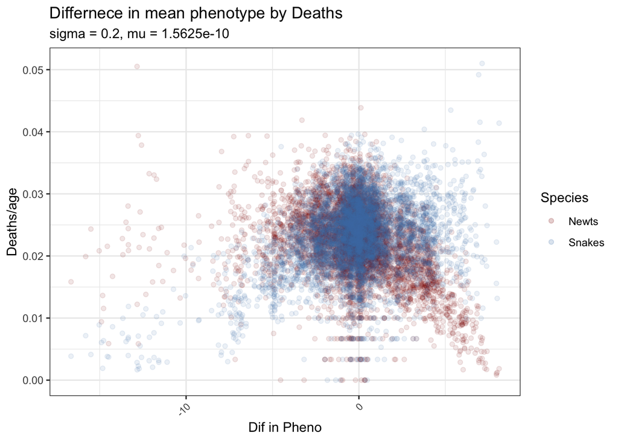

I thought the results were strange (seems like less newts dying when snake phenotype is higher) so I looked into further into what might be happening. I recorded the number of newt and snake deaths (cause by the other species) every 20 generations and recorded the population sizes for each species.

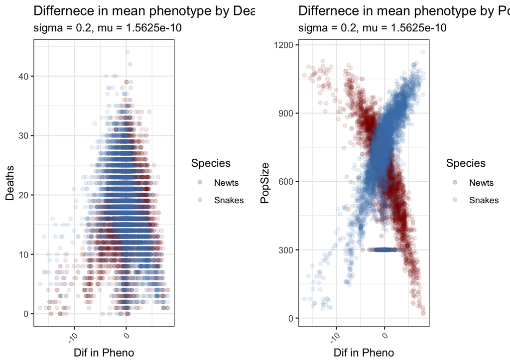

I found that there was an interaction between the difference in phenotype of newts and snakes and survivability of sorts. When the phenotype of the snake is higher less snakes were dying, but so where less newts. Less newts dying is probably due to the population size of newts being diminished when the phenotype of the snake is high. It’s possible that the most resistant snakes ate all of the newts in that area and just had fewer newts to eat. The reverse also happens when newts have a higher phenotype. There are less snakes and newts dying, bit the population size of snakes is small. Red and blue xmas tree and X marks the spot.

Next, I look into the betas and am not sure what I expect. I know the interaction between newts and snakes is small each generation, but there seems to be some interaction between phenotype and the ability for an individual to survive.

Lets look at the distribution

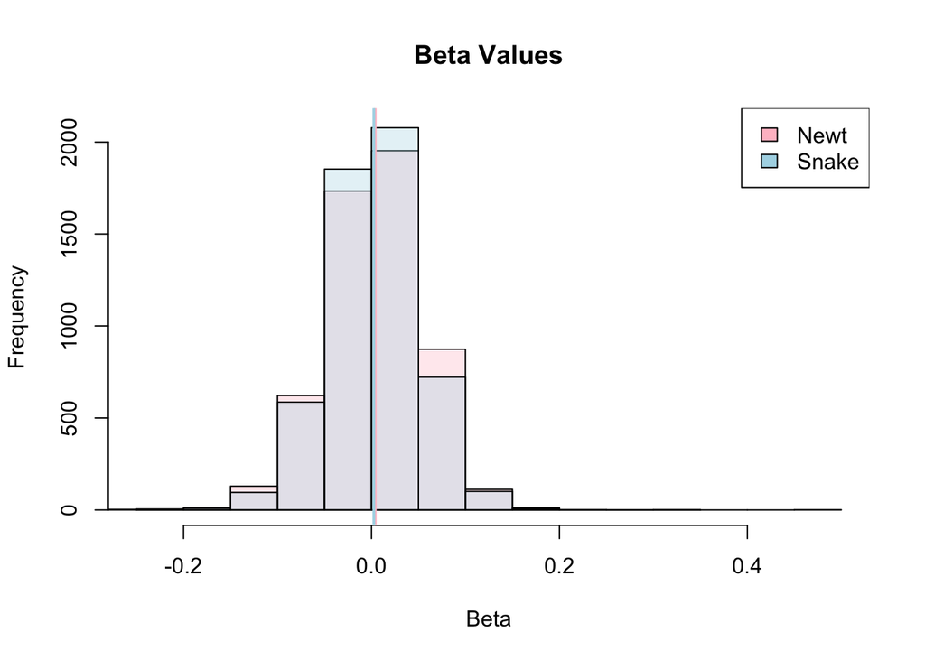

The beta values for newts and snakes seem to be similar. The means are also very close.

Lets plot the beta values for the newt against the beta values for the snake.

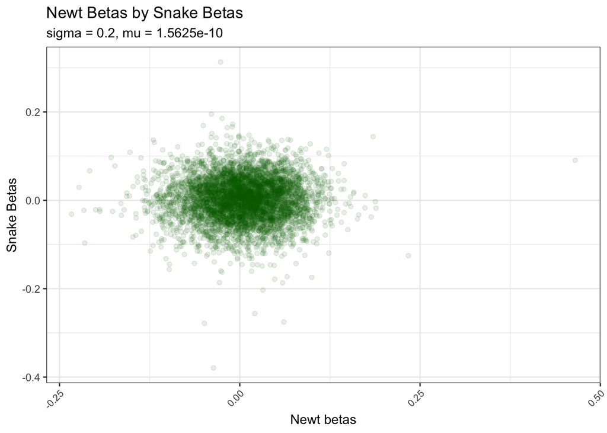

I present to you the green eyeball. It looks like there is no correlation between newt beta values and snake beta values. Prediction: this might be due to space, some areas might have correlation while other don’t. **This is one value for the entire area**

Finally, the last few graphs are extra things to look at.

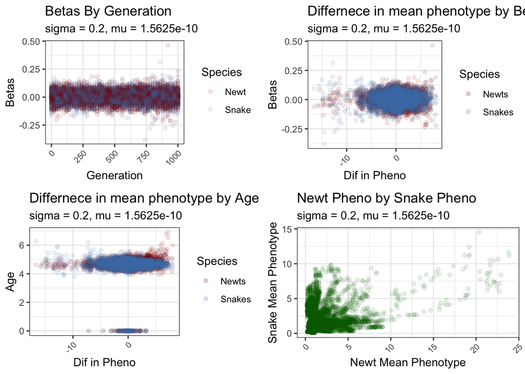

## The interaction of Newts and Snakes

I was wondering how often newts and snakes interact in a SLiMulation so I had SLiM print out four values, snake_found_newt (when a snake was potentially able to find a newt), newt_found (a snake found a newt), snake_deaths (snakes that were killed by newts), and newt_deaths (newts that were eaten by snakes). I also added the population size for newts and snakes to see in the number of interactions depend on the population size - which is linked to density. It looks like one the population size stabilizes (around 100 generations) there are 30-60 interactions each generation. Today 8/30/2021 I will run 20 of the same simulation to see if I can get a consensus on how many times newts and snake interact in each generation. Once I get this value I can plug it into nospace.slim to compare the results of the same simulation to a simulation with a lack of space. This will hopefully help me understand how space effects the coevolution of newts and snakes

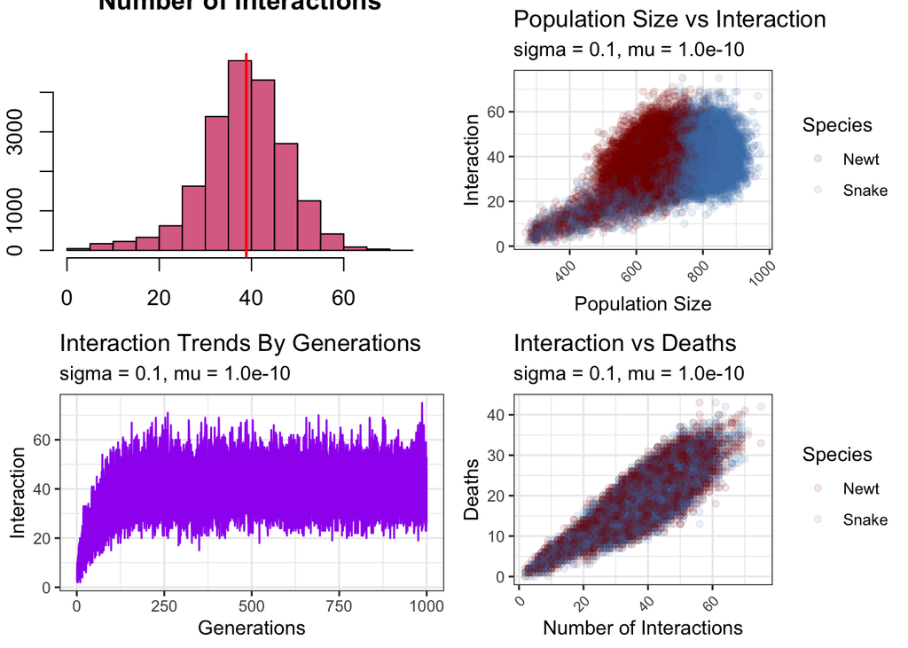